# Google Play Store Analysis

B05401102

2018年11月15日

#### **Data來源**： [kaggle-googleplaystore](https://www.kaggle.com/lava18/google-play-store-apps)

#### **說明**：

- 此dataset出自於kaggle網站，包含google play store中約10000個app的資訊。
- 此次Data Visualization目的是為了解不同類型的App在數量上有沒有差異，研究Rating(評分)的分布，並探討Rating與Installs(下載次數)之間有何關聯。
- 進行Data Visualization的流程包含Data Input, Data Cleaning, Plotting, 以及text mining的步驟。

### **1. Data Input**

> 直接從網站下載檔案後開啟。  
> 設置`stringsAsFactors = F`，輸入的資料型態才不會跑掉。  
> 原本讀取檔案後發現中文字導致亂碼，所以先利用記事本將dataset以新的編碼方式另存新檔，再開啟即可。

```r
#讀取googleplaystore.csv檔
googleplay<-read.delim("googleplaystore.csv", sep = ",",header = T, stringsAsFactors = F)
```

### **2. Data Cleaning**

> 將各column的資料型態改為適合進行分析的型態。  
> 使用gsub函數刪除不想要的字串符號後就可以順利將字串轉換為數字。

```r
#資料清洗與資料型態的轉變
googleplay$Category<-as.factor(googleplay$Category)
googleplay$Reviews<-as.numeric((googleplay$Reviews))
googleplay$Price<-as.numeric(gsub("[$]","",googleplay$Price))
googleplay$Installs<-as.numeric(gsub("[+,]","",googleplay$Installs))
googleplay$Type<-as.factor(googleplay$Type)
```

```
以下顯示清洗後dataset的一小部分。
```

| App | Category | Rating | Reviews | Size | Installs | Type | Price | Content.Rating | Genres | Last.Updated | Current.Ver | Android.Ver |
| --- | --- | --- | --- | --- | --- | --- | --- | --- | --- | --- | --- | --- |
| Photo Editor & Candy Camera & Grid & ScrapBook | ART_AND_DESIGN | 4.1 | 159 | 19M | 1e+04 | Free | 0 | Everyone | Art & Design | 7-Jan-18 | 1.0.0 | 4.0.3 and up |
| Coloring book moana | ART_AND_DESIGN | 3.9 | 967 | 14M | 5e+05 | Free | 0 | Everyone | Art & Design;Pretend Play | 15-Jan-18 | 2.0.0 | 4.0.3 and up |
| U Launcher Lite – FREE Live Cool Themes, Hide Apps | ART_AND_DESIGN | 4.7 | 87510 | 8.7M | 5e+06 | Free | 0 | Everyone | Art & Design | 1-Aug-18 | 1.2.4 | 4.0.3 and up |
| Sketch - Draw & Paint | ART_AND_DESIGN | 4.5 | 215644 | 25M | 5e+07 | Free | 0 | Teen | Art & Design | 8-Jun-18 | Varies with device | 4.2 and up |
| Pixel Draw - Number Art Coloring Book | ART_AND_DESIGN | 4.3 | 967 | 2.8M | 1e+05 | Free | 0 | Everyone | Art & Design;Creativity | 20-Jun-18 | 1.1 | 4.4 and up |
| Paper flowers instructions | ART_AND_DESIGN | 4.4 | 167 | 5.6M | 5e+04 | Free | 0 | Everyone | Art & Design | 26-Mar-17 | 1 | 2.3 and up |

### **3. Plotting**

> 開始進入重點，畫圖！首先引入ggplot2 package

```r
library(ggplot2)
```

### a) App types:

> 根據不同類型的app數量繪製長條圖。

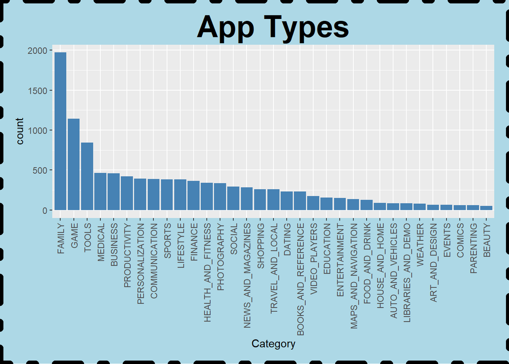

```
可見Family, Game, Tools這三種類的app數量最多
```

```r
my.plot_a <- ggplot(googleplay, aes(x = Category)) + scale_x_discrete(limits =   names(sort(table(googleplay$Category), decreasing = TRUE))) + layer(
  geom = "bar",  stat = "count",  position = "identity",
  params = list(
    fill = "steelblue",  binwidth = 0.1,  na.rm = FALSE
  )
)  + labs(title = "App Types") + theme(
  plot.background = element_rect(colour = "black",size = 3, linetype = 4, fill = "lightblue"),
  plot.title = element_text(colour = "black", face = "bold", size = 30, vjust = 1, hjust = 0.5),
  plot.margin = unit(c(0.2, 0.2, 0.2, 0.2), "inches"),
  axis.text.x = element_text(angle = 90, family = "Calibri", hjust = 1, vjust = 0.5)
)
my.plot_a
```

### b) Rating Distribution:

> 根據所有app評分(1~5)的分布情形繪製density curve

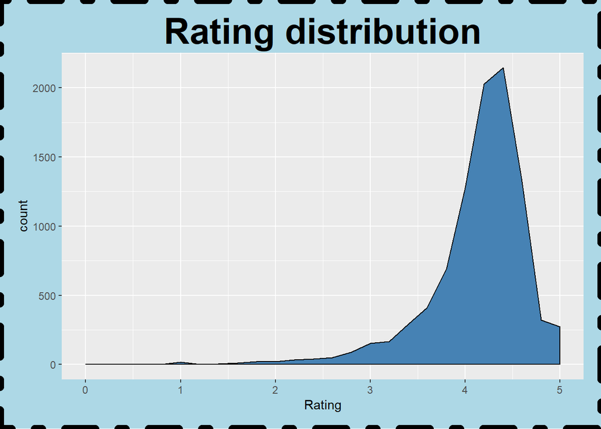

```
多數App的平均Rating在4~4.5之間。
```

```r
my.plot_b <- ggplot(googleplay, aes(x = Rating))+ xlim(0, 5) + layer(
  geom = "density",  stat = "bin",  position = "identity",  params = list(
    fill = "steelblue",
    binwidth = 0.2,
    na.rm = FALSE
  )
)  + labs(title = "Rating distribution") + theme(
  plot.background = element_rect(colour = "black",size = 3, linetype = 4, fill = "lightblue"),
  plot.title = element_text(colour = "black", face = "bold", size = 30, vjust = 1, hjust = 0.5),
  plot.margin = unit(c(0.2, 0.2, 0.2, 0.2), "inches")
)
my.plot_b
```

### c) Rating vs Installs:

> 將Installs(下載次數)由小到大分為6個level，繪製Rating的box plot

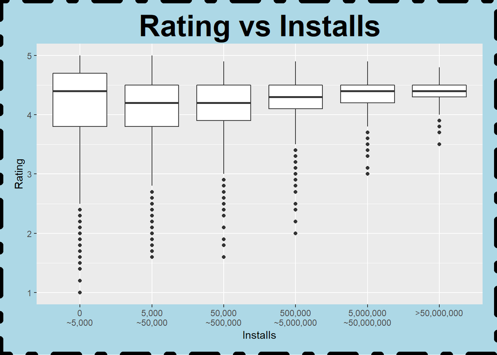

```
本來預期下載次數越多的App，Rating會比較好。圖表證明了這個猜測是對的，不過Rating變化也不大。有趣的是，在Installs<5000中，可以發現平均Rating反而比較高。另外，outlier的分布與installs大小呈現明顯的正相關，也是個值得探討的現象。
```

```r
b_ins<- c(0, 5000, 50000, 500000,5000000, 50000000, Inf)
lev_ins<- c("0\n~5,000", "5,000\n~50,000", "50,000\n~500,000", "500,000\n~5,000,000", "5,000,000\n~50,000,000", ">50,000,000")
my.plot_c <- ggplot(na.omit(googleplay), aes(x = cut(na.omit(googleplay)$Installs, breaks = b_ins, labels = lev_ins), y = Rating)) +  geom_boxplot()  + labs(title = "Rating vs Installs", x = "Installs") + theme(
  plot.background = element_rect(colour = "black",size = 3, linetype = 4, fill = "lightblue"),
  plot.title = element_text(colour = "black", face = "bold", size = 30, vjust = 1, hjust = 0.5),
  plot.margin = unit(c(0.2, 0.2, 0.2, 0.2), "inches")
)
my.plot_c
```

### d) text mining

> 因為從Ratings看不太出來Installs的線索，所以我想對app名稱進行text mining，看看app名稱和Installs有沒有關聯。 將所有app根據installs次數多寡分為三個level，分別擷取app名稱後進行text mining。

```r
library(NLP)
library(tm)
library(stats)
library(dplyr)
```

```r
library(readtext)
library(slam)
library(Matrix)
library(tidytext)
library(stringr)
library(wordcloud2)
library(ggplot2)
library(rvest)
library(SnowballC)
library(RColorBrewer)
library(wordcloud)


orderGoogleplay <- googleplay[order(googleplay$Installs, decreasing = T),]
na <- orderGoogleplay[1:3600,"App"]
nb <- orderGoogleplay[3601:7200,"App"]
nc <- orderGoogleplay[7201:nrow(orderGoogleplay),"App"]
alln <- list(na, nb, nc)
docs = Corpus(VectorSource(alln))
toSpace <- content_transformer(function(x, pattern) {
  return (gsub(pattern, " ", x))
})
docs <- tm_map(docs, removePunctuation)
docs <- tm_map(docs, removeNumbers)
docs <- tm_map(docs, stripWhitespace)
docs <- tm_map(docs, content_transformer(tolower))
docs <- tm_map(docs, removeWords, stopwords("english"))

tokenizer = function(d){
  unlist(strsplit(d[[1]], split = " "))
}
seg = lapply(docs, tokenizer)
```

> 分別建立term frequency的table。

```r
  termfreqa <- table(unlist(seg[[1]])) %>% sort(., decreasing =T )
  print(termfreqa[2:31])
```

```
##
##     free      app    photo     live   camera     news   editor    video
##      268      130      117      109       98       96       94       93
##        –     chat   google       tv    games    learn shopping  tracker
##       88       86       85       66       62       56       55       54
##   mobile        d     game   sports   dating    deals    calls   selfie
##       52       50       50       50       47       47       45       44
##   online  browser  manager     meet   scores     fast
##       43       41       41       38       38       35
```

```r
  termfreqb <- table(unlist(seg[[2]])) %>% sort(., decreasing =T )
  print(termfreqb[2:31])
```

```
##
##      free       app    mobile       pro    dating      news         d
##       185       117        79        71        69        66        60
##     video     theme simulator      game      chat      live  launcher
##        59        56        52        51        50        49        46
##     games         –    remote   android    camera      kids   english
##        45        44        44        43        39        39        38
##    number         x        tv   weather   manager        ac       car
##        37        37        36        36        34        33        33
##     learn     color
##        33        32
```

```r
  termfreqc <- table(unlist(seg[[3]])) %>% sort(., decreasing =T )
  print(termfreqc[2:31])
```

```
##
##        pro     mobile        app       free calculator      theme
##        102         92         88         62         58         53
##       chat wallpapers      video         eu         hd         ah
##         49         46         42         41         41         40
##         cg         ct         dx         db         dm         fk
##         40         39         39         38         38         38
##       live         bg         fe         ag         cf       news
##         38         37         37         35         35         35
##         aj         dw         ec    florida         ey         cb
##         34         34         34         34         32         31
```

```
從這三個table當中，最上面代表的是install次數比較多的app的term frequency。
從中可以觀察到幾個有趣的現象。
1. 名稱中含有"free" 的app的確比較受歡迎，相對於通常需要付費的"pro"而言。
2. 第一個table中，"camera"、"photo"、"editor"、"video"、"selfie"占了很大一部分，可見現代的人都愛當網帥網美XD。
3. 除了拍照方面，"shopping"、"dating"、"games"也是熱門下載的對象
4. 跟學習有關的，像是"english"、"calculator"，或是"weather"似乎是常見實用但沒那麼受歡迎的app。
```

> 接下來繪製文字雲。由於`wordcloud2`這個function存取的文字雲為動態(dynamic)的文字雲，要同時在一份markdown文件中顯示兩個文字雲的話，就必須把動態文字雲利用**htmlwidgets package**和**webshot package**存成靜態png檔再匯入，才能顯示。

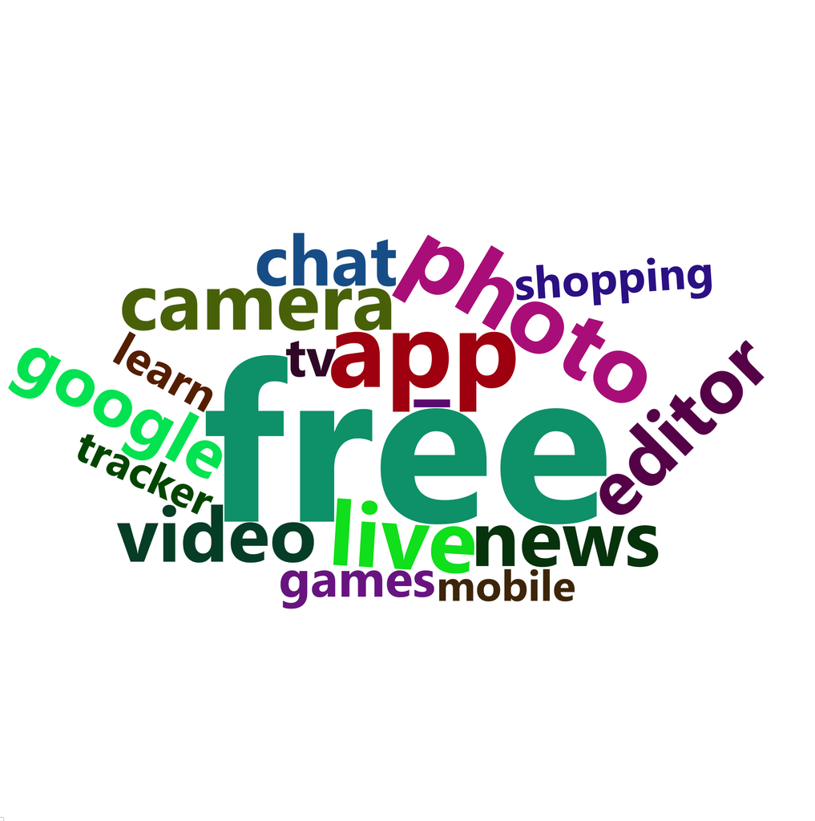

```r
library(htmlwidgets)
library(webshot)
a_cloud <- wordcloud2(as.data.frame(table(unlist(seg[[1]])) %>% sort(., decreasing =T )),size = 10)
saveWidget(a_cloud, "a.html", selfcontained = F)
webshot("a.html", "a.png", delay = 5, vwidth = 2000, vheight = 2000)
```

[figure not shown]

```r
b_cloud <- wordcloud2(as.data.frame(table(unlist(seg[[2]])) %>% sort(., decreasing =T )),size = 13)
saveWidget(b_cloud, "b.html", selfcontained = F)
webshot("b.html", "b.png", delay = 5, vwidth = 2000, vheight = 2000)
```

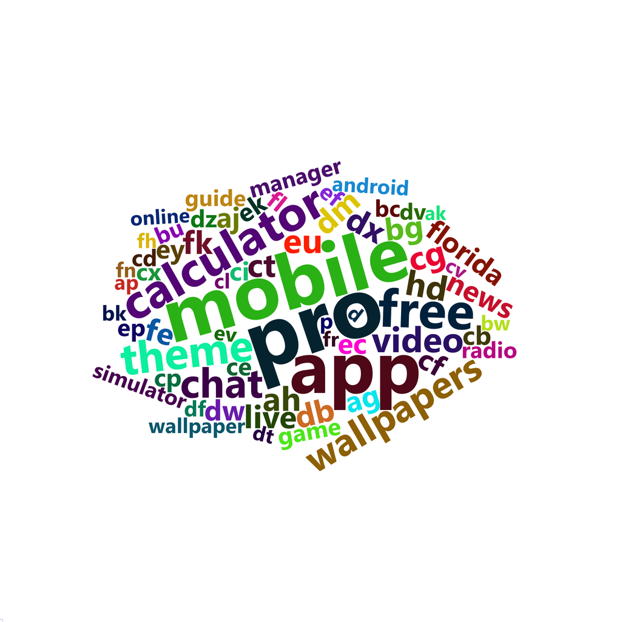

```r
c_cloud <- wordcloud2(as.data.frame(table(unlist(seg[[3]])) %>% sort(., decreasing =T )),size = 10)
saveWidget(c_cloud, "c.html", selfcontained = F)
webshot("c.html", "c.png", delay = 5, vwidth = 2000, vheight = 2000)
```